# Customer Segmentation and Targeting Model Showcase

## Introduction: The Task

This is a customer segmentation and targeting model I built for a leading payment processing platform in 2024 that uses a hybrid approach of rule-based filtering, **RFM** (Recency, Frequency, Monetary Value) analysis and K-Means clustering to select strong merchant based on their transaction activity.

For this showcase I will act as if I am collaborating with the Head of Product to encourage more existing users to adopt the Subscription payments product of a leading payment processing platform. The ultimate goal is to identify a list of new-to-Subscriptions users for a targeted sales or marketing campaign.

## EDA & Data Cleaning

### Imports & Data Load

```python
import pandas as pd
import numpy as np
from datetime import datetime
import matplotlib.pyplot as plt
import matplotlib.cm as cm
from mpl_toolkits.mplot3d import Axes3D
import seaborn as sns
from sklearn.compose import ColumnTransformer
from sklearn.preprocessing import StandardScaler
from sklearn.cluster import KMeans
from sklearn.metrics import silhouette_score
from ydata_profiling import ProfileReport
```

```python
# Load data
raw_payments_df = pd.read_csv('Data/payments.csv', parse_dates = ['date'])
raw_merchants_df = pd.read_csv('Data/merchants.csv')

print(raw_payments_df.info())
print(raw_merchants_df.info())
```

```
<class 'pandas.core.frame.DataFrame'>
RangeIndex: 1577887 entries, 0 to 1577886
Data columns (total 6 columns):
 #   Column               Non-Null Count    Dtype
---  ------               --------------    -----
 0   date                 1577887 non-null  datetime64[ns, UTC]
 1   merchant             1577887 non-null  object
 2   subscription_volume  1577887 non-null  int64
 3   checkout_volume      1577887 non-null  int64
 4   payment_link_volume  1577887 non-null  int64
 5   total_volume         1577887 non-null  int64
dtypes: datetime64[ns, UTC](1), int64(4), object(1)
memory usage: 72.2+ MB
None
<class 'pandas.core.frame.DataFrame'>
RangeIndex: 23627 entries, 0 to 23626
Data columns (total 5 columns):
 #   Column             Non-Null Count  Dtype
---  ------             --------------  -----
 0   merchant           23627 non-null  object
 1   industry           23627 non-null  object
 2   first_charge_date  23627 non-null  object
 3   country            23627 non-null  object
 4   business_size      23627 non-null  object
dtypes: object(5)
memory usage: 923.1+ KB
None
```

#### Examine Merchants

```python
# Describe merchants
print(raw_merchants_df.head())
raw_merchants_df.describe()
```

```
   merchant           industry          first_charge_date country  \
0  5d03e714          Education  2032-02-13 00:00:00+00:00      US
1  da22f154             Others  2031-10-16 00:00:00+00:00      US
2  687eebc8           Software  2032-07-23 00:00:00+00:00      US
3  de478470           Software  2033-03-15 00:00:00+00:00      US
4  1e719b8a  Business services  2035-02-12 00:00:00+00:00      IT

  business_size
0        medium
1         small
2         small
3         small
4         small
```

|  | merchant | industry | first_charge_date | country | business_size |
| --- | --- | --- | --- | --- | --- |
| count | 23627 | 23627 | 23627 | 23627 | 23627 |
| unique | 23619 | 30 | 2872 | 44 | 3 |
| top | 0.00E+0 | Business services | 2041-10-27 00:00:00+00:00 | US | small |
| freq | 8 | 3144 | 43 | 8595 | 22853 |

```python
# Check unique values and their counts for categorical columns
industry_counts = raw_merchants_df['industry'].value_counts()
country_counts = raw_merchants_df['country'].value_counts()
business_size_counts = raw_merchants_df['business_size'].value_counts()

industry_counts, country_counts, business_size_counts

# Note: industry has value of "0", business_size has class imbalance, country has a few countries with very low counts
```

```
(industry
 Business services                                           3144
 Software                                                    2167
 Merchandise                                                 1988
 Personal services                                           1922
 Others                                                      1732
 Digital goods                                               1379
 Education                                                   1332
 Clothing & accessory                                        1303
 Food & drink                                                1275
 Grocery & food stores                                        780
 Religion, politics & other memberships                       762
 Travel & lodging                                             727
 Leisure                                                      554
 Art & photography                                            508
 Charity                                                      502
 Medical services, drugs, testing labs & equipment medium     435
 Ticketing & events                                           425
 Furnishing                                                   419
 Cosmetics                                                    399
 Specialty retail                                             384
 Rentals                                                      350
 Automotive parts and repair/service shops                    258
 Construction                                                 221
 Healthcare                                                   204
 Electronics                                                  194
 Transportation & car rental                                  189
 Consulting services                                           50
 Insurance                                                     14
 0                                                              7
 Money transmitters                                             3
 Name: count, dtype: int64,
 country
 US    8595
 GB    3478
 FR    1700
 AU    1378
 CA    1324
 ES     926
 IT     821
```

[output cut: 28 more lines]

```
 GR      44
 LV      43
 HU      37
 LU      27
 CY      26
 MT      20
 HR       7
 TH       1
 GI       1
 Name: count, dtype: int64,
 business_size
 small     22853
 medium      622
 large       152
 Name: count, dtype: int64)
```

#### Examine Payments

```python
# Describe payments
print(raw_payments_df.head())
raw_payments_df.describe(include = 'all')
```

```
                       date  merchant  subscription_volume  checkout_volume  \
0 2041-05-01 00:00:00+00:00  5d03e714                    0                0
1 2041-05-01 00:00:00+00:00  da22f154                    0                0
2 2041-05-01 00:00:00+00:00  687eebc8                79400                0
3 2041-05-01 00:00:00+00:00  de478470               268400                0
4 2041-05-01 00:00:00+00:00  1e719b8a                    0            19895

   payment_link_volume  total_volume
0                    0        425340
1                    0         17326
2                    0         79400
3                    0        268400
4                    0         19895
```

|  | date | merchant | subscription_volume | checkout_volume | payment_link_volume | total_volume |
| --- | --- | --- | --- | --- | --- | --- |
| count | 1577887 | 1577887 | 1.577887e+06 | 1.577887e+06 | 1.577887e+06 | 1.577887e+06 |
| unique | NaN | 23619 | NaN | NaN | NaN | NaN |
| top | NaN | de478470 | NaN | NaN | NaN | NaN |
| freq | NaN | 418 | NaN | NaN | NaN | NaN |
| mean | 2041-12-02 00:57:55.029073408+00:00 | NaN | 3.924766e+04 | 1.101376e+04 | 1.843901e+03 | 3.582914e+05 |
| min | 2041-05-01 00:00:00+00:00 | NaN | 0.000000e+00 | 0.000000e+00 | 0.000000e+00 | 1.000000e+00 |
| 25% | 2041-08-21 00:00:00+00:00 | NaN | 0.000000e+00 | 0.000000e+00 | 0.000000e+00 | 6.000000e+03 |
| 50% | 2041-12-05 00:00:00+00:00 | NaN | 0.000000e+00 | 0.000000e+00 | 0.000000e+00 | 1.987200e+04 |
| 75% | 2042-03-17 00:00:00+00:00 | NaN | 0.000000e+00 | 0.000000e+00 | 0.000000e+00 | 7.230000e+04 |
| max | 2042-06-22 00:00:00+00:00 | NaN | 1.083879e+08 | 3.425907e+07 | 1.182900e+07 | 2.243810e+09 |
| std | NaN | NaN | 7.253647e+05 | 1.608574e+05 | 3.717659e+04 | 6.488684e+06 |

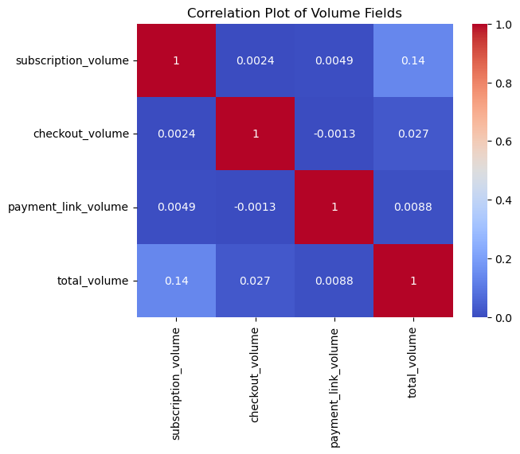

```python
# Generate corr plot of payment volume

volume_columns = [col for col in raw_payments_df.columns if col.endswith('_volume')]
volume_df = raw_payments_df[volume_columns]
correlation = volume_df.corr()

sns.heatmap(correlation, annot=True, cmap='coolwarm')
plt.title('Correlation Plot of Volume Fields')
plt.show()
```

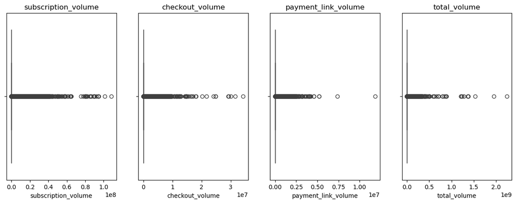

```python
# Box and whisker plots
fig, axs = plt.subplots(1, len(volume_columns), figsize=(15, 5))

for i, column in enumerate(volume_columns):
    sns.boxplot(x=raw_payments_df[column], ax=axs[i])
    axs[i].set_title(column)

plt.show()
```

### Data Cleaning

#### Clean Payments

```python
# Clean payments to parse dates
raw_payments_df['date'] = pd.to_datetime(raw_payments_df['date'])
# Convert Cents to Dollars for all columns ending in _volume
volume_columns = [col for col in raw_payments_df.columns if col.endswith('_volume')]
raw_payments_df[volume_columns] = raw_payments_df[volume_columns] / 100

payments_df = raw_payments_df.copy()
payments_df.dtypes
```

```
date                   datetime64[ns, UTC]
merchant                            object
subscription_volume                float64
checkout_volume                    float64
payment_link_volume                float64
total_volume                       float64
dtype: object
```

#### Clean Merchants

```python
# Review & handle duplicate merchant
print(raw_merchants_df[raw_merchants_df.duplicated(subset = ['merchant'])])
dups_row = raw_merchants_df.duplicated(subset = ['merchant'], keep = False)
print(raw_merchants_df[dups_row])
# Remove any duplicate merchant id
raw_merchants_df = raw_merchants_df[~dups_row]

# Drop first charge dates of 0 from data and parse dates
no_charge_date_mask = raw_merchants_df['first_charge_date'] == "0"
raw_merchants_df = raw_merchants_df[~no_charge_date_mask]
raw_merchants_df['first_charge_date'] = pd.to_datetime(raw_merchants_df['first_charge_date'])

# Drop rows with industry 0
raw_merchants_df = raw_merchants_df[raw_merchants_df['industry'] != "0"]

merchants_df = raw_merchants_df.copy()
print(merchants_df.dtypes)
print(merchants_df.shape)
```

```
       merchant           industry          first_charge_date country  \
11606   0.00E+0        Merchandise  2038-11-30 00:00:00+00:00      CA
13020   0.00E+0          Education  2041-07-15 00:00:00+00:00      MX
13304  4.72E+10          Education  2041-01-20 00:00:00+00:00      IT
13384   0.00E+0             Others  2041-07-24 00:00:00+00:00      GB
18458   0.00E+0  Business services  2041-12-16 00:00:00+00:00      US
20739   0.00E+0             Others  2042-03-10 00:00:00+00:00      US
21151   0.00E+0             Others  2042-03-26 00:00:00+00:00      GB
22686   0.00E+0            Leisure  2042-05-22 00:00:00+00:00      SG

      business_size
11606         small
13020         small
13304         small
13384         small
```

[output cut: 34 more lines]

### Data Wrangling & Feature Engineering

#### Merchant Features

```python
# Create last_date reference based on payments data
last_date = payments_df['date'].max()
print(last_date)

# Create new column called merchant_age_mos
merchants_df['merchant_age_mos'] = (last_date - merchants_df['first_charge_date']).dt.days // 30.44
#drop merchant_age column
merchants_df.head()
```

```
2042-06-22 00:00:00+00:00
```

|  | merchant | industry | first_charge_date | country | business_size | merchant_age_mos |
| --- | --- | --- | --- | --- | --- | --- |
| 0 | 5d03e714 | Education | 2032-02-13 00:00:00+00:00 | US | medium | 124.0 |
| 1 | da22f154 | Others | 2031-10-16 00:00:00+00:00 | US | small | 128.0 |
| 2 | 687eebc8 | Software | 2032-07-23 00:00:00+00:00 | US | small | 118.0 |
| 3 | de478470 | Software | 2033-03-15 00:00:00+00:00 | US | small | 111.0 |
| 4 | 1e719b8a | Business services | 2035-02-12 00:00:00+00:00 | IT | small | 88.0 |

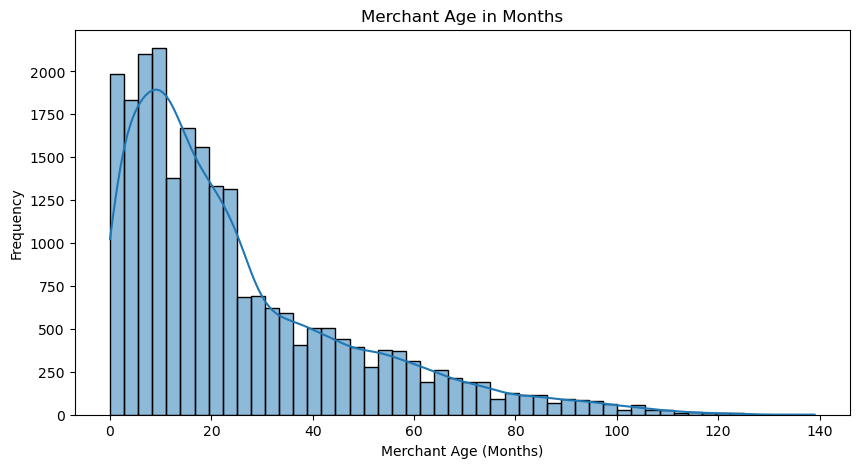

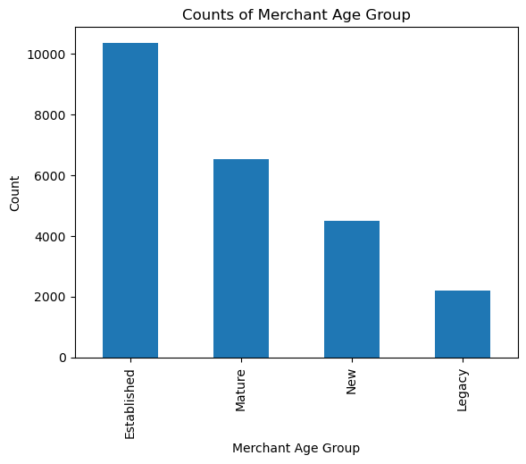

|  | merchant | industry | country | business_size | merchant_age_group |
| --- | --- | --- | --- | --- | --- |
| 0 | 5d03e714 | Education | US | medium | Legacy |
| 1 | da22f154 | Others | US | small | Legacy |
| 2 | 687eebc8 | Software | US | small | Legacy |
| 3 | de478470 | Software | US | small | Legacy |
| 4 | 1e719b8a | Business services | IT | small | Legacy |

```python
# Define conditions for np.select
conditions = [
    (merchants_df['merchant_age_mos'] <= 6),
    (merchants_df['merchant_age_mos'] > 6) & (merchants_df['merchant_age_mos'] <= 24),
    (merchants_df['merchant_age_mos'] > 24) & (merchants_df['merchant_age_mos'] <= 60),
    (merchants_df['merchant_age_mos'] > 60)
]

# Define corresponding labels
choices = ['New', 'Established', 'Mature', 'Legacy']
# Use np.select to create the 'merchant_age_group' column
merchants_df['merchant_age_group'] = np.select(conditions, choices, default='Unknown')



# Merchant age in months histogram
plt.figure(figsize=(10, 5))
sns.histplot(merchants_df['merchant_age_mos'], bins=50, kde=True)
plt.title('Merchant Age in Months')
plt.xlabel('Merchant Age (Months)')
plt.ylabel('Frequency')
plt.show()

# Merchant age group plot
merchants_df['merchant_age_group'].value_counts().plot(kind='bar')
plt.title('Counts of Merchant Age Group')
plt.xlabel('Merchant Age Group')
plt.ylabel('Count')
plt.show()

# Drop merchant age column
merchants_df = merchants_df.drop(columns = ['first_charge_date','merchant_age_mos'], axis = 1)
merchants_df.head()
```

```python
# Merge and evaluate data

distinct_merchants = payments_df['merchant'].nunique()
print("Number of distinct merchants in payments:", distinct_merchants)
print(payments_df.shape)

distinct_merchants = merchants_df['merchant'].nunique()
print("Number of distinct merchants in merchants:", distinct_merchants)
print(merchants_df.shape)

# Merge payments and merchants data using inner join
payments_merchants_df = payments_df.merge(merchants_df, on='merchant', how='inner')
print("number of distinct merchants in merged data:", payments_merchants_df['merchant'].nunique())
print(payments_merchants_df.shape)

# Merchants in payments_df but not in merchants_df
missing_in_merchants = payments_df[~payments_df['merchant'].isin(merchants_df['merchant'])]
# Merchants in merchants_df but not in payments_df
missing_in_payments = merchants_df[~merchants_df['merchant'].isin(payments_df['merchant'])]
print("Merchants in payments_df but not in merchants_df:", missing_in_merchants['merchant'].nunique())
print("Merchants in merchants_df but not in payments_df:", missing_in_payments['merchant'].nunique())
```

```
Number of distinct merchants in payments: 23619
(1577887, 6)
Number of distinct merchants in merchants: 23584
(23584, 5)
number of distinct merchants in merged data: 23557
(1574955, 10)
Merchants in payments_df but not in merchants_df: 62
Merchants in merchants_df but not in payments_df: 27
```

#### Business Size Additional Charts

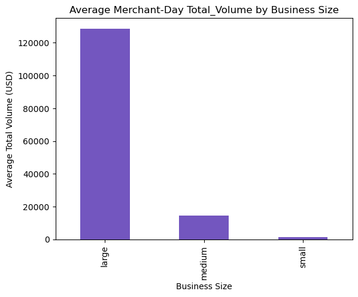

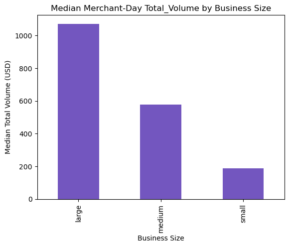

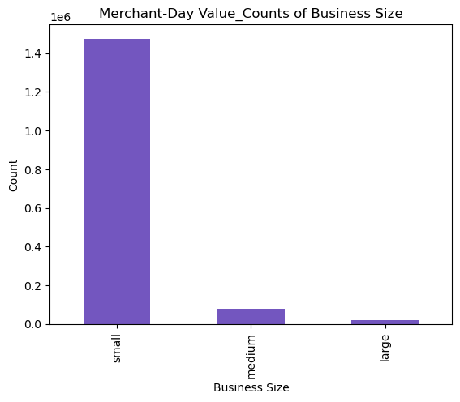

```python
payments_merchants_df.groupby('business_size')['total_volume'].mean().plot(kind='bar', color='#7356BF')
plt.title('Average Merchant-Day Total_Volume by Business Size')
plt.xlabel('Business Size')
plt.ylabel('Average Total Volume (USD)')
plt.show()

payments_merchants_df.groupby('business_size')['total_volume'].median().plot(kind='bar', color='#7356BF')
plt.title('Median Merchant-Day Total_Volume by Business Size')
plt.xlabel('Business Size')
plt.ylabel('Median Total Volume (USD)')
plt.show()

payments_merchants_df['business_size'].value_counts().plot(kind='bar', color='#7356BF')
plt.title('Merchant-Day Value_Counts of Business Size')
plt.xlabel('Business Size')
plt.ylabel('Count')
plt.show()
```

#### Apply Rule Based Filtering to Payments Data

RULE BASED FILTER

I applied initial rule-based filters to narrow down the broad customer segments. The focus was on excluding merchants already using Subscriptions, targeting those with recent activity over a volume threshold and concentrating on small and medium businesses (SMBs). By filtering out larger enterprises, the analysis became scalable and focused on the merchant segment most likely to quickly adopt Subscriptions.

```python
# 1. Identify non-subscription users by summing the subscription_volume per merchant
merchant_subscription_sum = payments_merchants_df.groupby('merchant')['subscription_volume'].sum()

## Filter merchants who have a total subscription_volume of 0
non_subscription_merchants = merchant_subscription_sum[merchant_subscription_sum == 0].index

## Filter the payments_merchants_df to only include  non-subscription merchants
non_subscription_merchants_df = payments_merchants_df[payments_merchants_df['merchant'].isin(non_subscription_merchants)]

# 2. Filter merchants with activity within the last 60 days
## Assign variable for the latest date in the payments df to use as a reference
# last_date = payments_merchants_df['date'].max()  # Already defined in code chunks above

cutoff_days = 60
recent_cutoff_date = last_date - pd.Timedelta(days=cutoff_days) # Cutoff date

# Filter transactions within the last 60 days
recent_transactions_df = non_subscription_merchants_df[non_subscription_merchants_df['date'] >= recent_cutoff_date]

# 3. Calculate total volume during the recent 60-day period for each merchant
recent_activity_total_volume = recent_transactions_df.groupby('merchant')['total_volume'].sum()

# Apply the volume threshold ($1,000 or 100,000 cents)
volume_threshold = 1000
active_merchants = recent_activity_total_volume[recent_activity_total_volume >= volume_threshold].index # Merchants with total volume >= $1,000 within the past 60 days

filtered_payments_merchants = non_subscription_merchants_df[non_subscription_merchants_df['merchant'].isin(active_merchants)]

# Keep only small and medium business sizes (SMB)
filtered_payments_merchants_df = filtered_payments_merchants[filtered_payments_merchants['business_size'].isin(['small', 'medium'])]

print(filtered_payments_merchants_df.shape)
print(filtered_payments_merchants_df.head())
filtered_payments_merchants_df.describe()
```

```
(882324, 10)
                       date  merchant  subscription_volume  checkout_volume  \
0 2041-05-01 00:00:00+00:00  5d03e714                  0.0             0.00
1 2041-05-01 00:00:00+00:00  da22f154                  0.0             0.00
4 2041-05-01 00:00:00+00:00  1e719b8a                  0.0           198.95
5 2041-05-01 00:00:00+00:00  15f61630                  0.0             0.00
7 2041-05-01 00:00:00+00:00  11f1600c                  0.0             0.00

   payment_link_volume  total_volume           industry country business_size  \
0                  0.0       4253.40          Education      US        medium
1                  0.0        173.26             Others      US         small
4                  0.0        198.95  Business services      IT         small
5                  0.0       3285.00           Software      US         small
7                  0.0       1100.00           Software      US         small

  merchant_age_group
0             Legacy
1             Legacy
4             Legacy
5             Legacy
7             Mature
```

|  | subscription_volume | checkout_volume | payment_link_volume | total_volume |
| --- | --- | --- | --- | --- |
| count | 882324.0 | 882324.000000 | 882324.000000 | 8.823240e+05 |
| mean | 0.0 | 151.297261 | 14.904575 | 2.098112e+03 |
| std | 0.0 | 2054.481887 | 344.322663 | 2.188005e+04 |
| min | 0.0 | 0.000000 | 0.000000 | 1.000000e-02 |
| 25% | 0.0 | 0.000000 | 0.000000 | 9.386000e+01 |
| 50% | 0.0 | 0.000000 | 0.000000 | 2.705600e+02 |
| 75% | 0.0 | 0.000000 | 0.000000 | 8.867300e+02 |
| max | 0.0 | 342590.690000 | 46039.270000 | 1.374812e+07 |

#### Apply RFM Engineering To Payments

RFM ENGINEERING & ANALYSIS

The use of RFM analysis enabled a way to segment merchants based on their engagement and value, forming the foundation for subsequent clustering. To quantify merchant engagement and value, I calculated Recency, Frequency, and Monetary (RFM) features—an approach commonly used in customer segmentation to identify distinct customer groups based on their transaction behavior.

```python
# 1. Recency: Calculate the number of days since the last transaction for each merchant
# Uses last_date as the reference point
recency = filtered_payments_merchants_df.groupby('merchant')['date'].max().apply(lambda x: (last_date - x).days)

# 2. Frequency: Count the number of transaction_volume days for each merchant
frequency = filtered_payments_merchants_df.groupby('merchant')['date'].count()

# 3. Monetary: Sum the total transaction volume for each merchant
monetary = filtered_payments_merchants_df.groupby('merchant')['total_volume'].sum()

# Combine RFM features into a single DataFrame
rfm_payments_df = pd.DataFrame({
    'merchant': recency.index,  # include merchant
    'recency': recency.values,
    'frequency': frequency.values,
    'monetary': monetary.values
})

grouped_filtered_payments_merchants_df = filtered_payments_merchants_df[
    ['merchant', 'industry', 'country', 'business_size', 'merchant_age_group']
].drop_duplicates().reset_index(drop=True)

rfm_payments_df = rfm_payments_df.merge(grouped_filtered_payments_merchants_df, on='merchant', how='inner')

print(rfm_payments_df.shape)
rfm_payments_df.head()
```

```
(6006, 8)
```

|  | merchant | recency | frequency | monetary | industry | country | business_size | merchant_age_group |
| --- | --- | --- | --- | --- | --- | --- | --- | --- |
| 0 | 001111d7 | 0 | 9 | 18659.95 | Transportation & car rental | SK | small | New |
| 1 | 003f950d | 8 | 9 | 9126.89 | Merchandise | CA | small | New |
| 2 | 00491f9d | 0 | 353 | 87327.98 | Personal services | IT | small | Mature |
| 3 | 005392db | 1 | 87 | 24719.02 | Travel & lodging | FR | small | Mature |
| 4 | 0076b5fd | 0 | 306 | 333604.62 | Digital goods | CA | small | Mature |

```
418
```

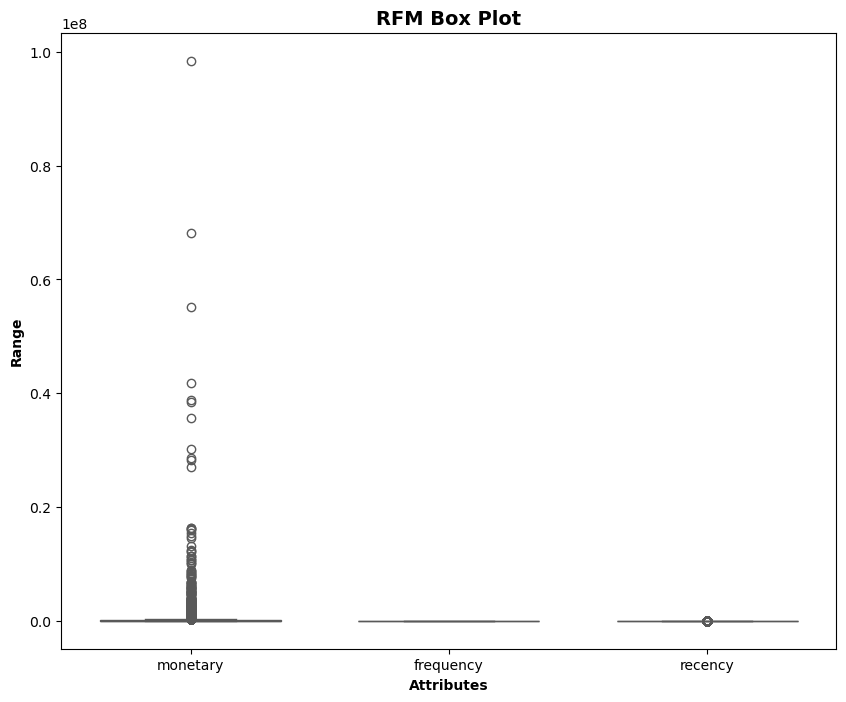

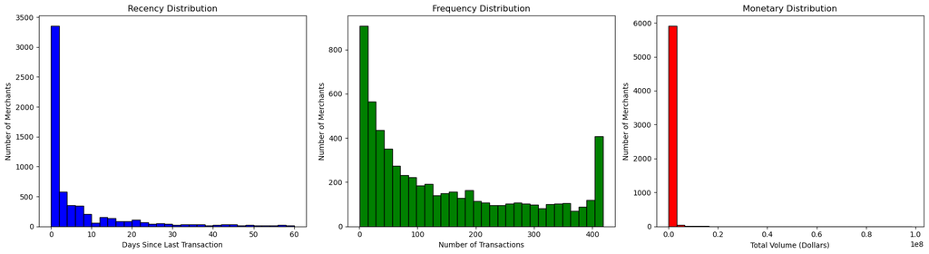

```python
print(rfm_payments_df.frequency.max())
# Setting up the attributes for the boxplot
attributes = ['monetary', 'frequency', 'recency']

# Plot the boxplot for RFM features
plt.rcParams['figure.figsize'] = [10, 8]
sns.boxplot(data=rfm_payments_df[attributes], orient="v", palette="Set2", whis=1.5, saturation=1, width=0.7)
plt.title("RFM Box Plot", fontsize=14, fontweight='bold')
plt.ylabel("Range", fontweight='bold')
plt.xlabel("Attributes", fontweight='bold')

plt.show()


# Plot the distribution of Recency, Frequency, and Monetary values
plt.figure(figsize=(18, 5))

# Recency Distribution
plt.subplot(1, 3, 1)
plt.hist(rfm_payments_df['recency'], bins=30, color='blue', edgecolor='black')
plt.title('Recency Distribution')
plt.xlabel('Days Since Last Transaction')
plt.ylabel('Number of Merchants')

# Frequency Distribution
plt.subplot(1, 3, 2)
plt.hist(rfm_payments_df['frequency'], bins=30, color='green', edgecolor='black')
plt.title('Frequency Distribution')
plt.xlabel('Number of Transactions')
plt.ylabel('Number of Merchants')

# Monetary Distribution
plt.subplot(1, 3, 3)
plt.hist(rfm_payments_df['monetary'], bins=30, color='red', edgecolor='black')
plt.title('Monetary Distribution')
plt.xlabel('Total Volume (Dollars)')
plt.ylabel('Number of Merchants')

plt.tight_layout()
plt.show()
```

##### Add Feature to RFM for Multi Product Users

```python
# Create a binary feature to indicate whether a merchant had Checkout or Payment Link volume
non_subscription_merchants_df.loc[:,'used_checkout_or_payment_link'] = (
    (non_subscription_merchants_df['checkout_volume'] > 0) |
    (non_subscription_merchants_df['payment_link_volume'] > 0)
).astype(int)

# Take the max to see whether they EVER used it
merchant_usage_feature = non_subscription_merchants_df.groupby('merchant')['used_checkout_or_payment_link'].max()

merchant_usage_feature_list = merchant_usage_feature.to_frame().reset_index()


# Merge to rfm_payments_df
rfm_payments_df = rfm_payments_df.merge(merchant_usage_feature_list, on='merchant', how='left')
rfm_payments_df.head(20)
```

|  | merchant | recency | frequency | monetary | industry | country | business_size | merchant_age_group | used_checkout_or_payment_link |
| --- | --- | --- | --- | --- | --- | --- | --- | --- | --- |
| 0 | 001111d7 | 0 | 9 | 18659.95 | Transportation & car rental | SK | small | New | 0 |
| 1 | 003f950d | 8 | 9 | 9126.89 | Merchandise | CA | small | New | 0 |
| 2 | 00491f9d | 0 | 353 | 87327.98 | Personal services | IT | small | Mature | 0 |
| 3 | 005392db | 1 | 87 | 24719.02 | Travel & lodging | FR | small | Mature | 0 |
| 4 | 0076b5fd | 0 | 306 | 333604.62 | Digital goods | CA | small | Mature | 0 |
| 5 | 007f783b | 0 | 418 | 12074538.61 | Merchandise | US | small | Mature | 0 |
| 6 | 0093ba4d | 0 | 416 | 991587.51 | Transportation & car rental | ES | small | Mature | 0 |
| 7 | 009dd2b6 | 2 | 76 | 166102.00 | Personal services | IT | small | Mature | 1 |
| 8 | 00a43c37 | 0 | 416 | 3413052.83 | Business services | US | small | Established | 0 |
| 9 | 00a7095f | 0 | 71 | 10223.00 | Personal services | US | small | Established | 0 |
| 10 | 00b55ff7 | 30 | 14 | 21604.89 | Clothing & accessory | AU | small | Legacy | 0 |
| 11 | 00c6049c | 10 | 32 | 8223.39 | Grocery & food stores | US | small | New | 1 |
| 12 | 00cfc07f | 6 | 335 | 177240.19 | Personal services | NL | small | Established | 1 |
| 13 | 00e3b995 | 2 | 158 | 23392.84 | Merchandise | FR | small | Mature | 0 |
| 14 | 00ea5a27 | 0 | 382 | 58441.58 | Food & drink | NZ | small | Mature | 0 |
| 15 | 00ef7320 | 0 | 251 | 1504137.16 | Business services | US | medium | Mature | 0 |
| 16 | 00f0c8c8 | 1 | 98 | 26497.18 | Cosmetics | ES | small | Mature | 0 |
| 17 | 010b0bb3 | 0 | 56 | 4808.17 | Merchandise | ES | small | Mature | 1 |
| 18 | 012258f6 | 0 | 243 | 1270698.16 | Business services | US | small | Mature | 1 |
| 19 | 012db28b | 5 | 53 | 61497.19 | Merchandise | HK | small | Mature | 0 |

```python
print(rfm_payments_df.shape)
print(rfm_payments_df.value_counts('used_checkout_or_payment_link', normalize = True))
rfm_payments_df.value_counts('used_checkout_or_payment_link')
```

```
(6006, 9)
used_checkout_or_payment_link
0    0.771895
1    0.228105
Name: proportion, dtype: float64
```

```
used_checkout_or_payment_link
0    4636
1    1370
Name: count, dtype: int64
```

##### Scale RFM Features

```python
# Scale the three RFM features using StandardScaler while ignoring the rest
ct = ColumnTransformer([
    ('scaler', StandardScaler(), ['recency', 'frequency', 'monetary']),  # Columns to scale
], remainder='passthrough')

rfm_scaled_array = ct.fit_transform(rfm_payments_df)

# Convert the transformed array back to a DataFrame
rfm_scaled_df = pd.DataFrame(rfm_scaled_array, columns=['recency', 'frequency', 'monetary', 'merchant', 'industry', 'country', 'business_size', 'merchant_age_group', 'used_checkout_or_payment_link'])

# Since the passthrough columns are added at the end, reordering columns for clarity
rfm_scaled_df = rfm_scaled_df[['merchant', 'recency', 'frequency', 'monetary', 'industry', 'country', 'business_size', 'merchant_age_group', 'used_checkout_or_payment_link']]

rfm_scaled_df.head(20)
```

|  | merchant | recency | frequency | monetary | industry | country | business_size | merchant_age_group | used_checkout_or_payment_link |
| --- | --- | --- | --- | --- | --- | --- | --- | --- | --- |
| 0 | 001111d7 | -0.551518 | -1.022015 | -0.125441 | Transportation & car rental | SK | small | New | 0 |
| 1 | 003f950d | 0.158825 | -1.022015 | -0.129571 | Merchandise | CA | small | New | 0 |
| 2 | 00491f9d | -0.551518 | 1.527334 | -0.095694 | Personal services | IT | small | Mature | 0 |
| 3 | 005392db | -0.462725 | -0.443965 | -0.122817 | Travel & lodging | FR | small | Mature | 0 |
| 4 | 0076b5fd | -0.551518 | 1.179021 | 0.010993 | Digital goods | CA | small | Mature | 0 |
| 5 | 007f783b | -0.551518 | 2.009042 | 5.097195 | Merchandise | US | small | Mature | 0 |
| 6 | 0093ba4d | -0.551518 | 1.99422 | 0.296033 | Transportation & car rental | ES | small | Mature | 0 |
| 7 | 009dd2b6 | -0.373932 | -0.525485 | -0.061569 | Personal services | IT | small | Mature | 1 |
| 8 | 00a43c37 | -0.551518 | 1.99422 | 1.345018 | Business services | US | small | Established | 0 |
| 9 | 00a7095f | -0.551518 | -0.56254 | -0.129096 | Personal services | US | small | Established | 0 |
| 10 | 00b55ff7 | 2.112266 | -0.984961 | -0.124166 | Clothing & accessory | AU | small | Legacy | 0 |
| 11 | 00c6049c | 0.33641 | -0.851565 | -0.129963 | Grocery & food stores | US | small | New | 1 |
| 12 | 00cfc07f | -0.018761 | 1.393937 | -0.056744 | Personal services | NL | small | Established | 1 |
| 13 | 00e3b995 | -0.373932 | 0.082208 | -0.123391 | Merchandise | FR | small | Mature | 0 |
| 14 | 00ea5a27 | -0.551518 | 1.74225 | -0.108208 | Food & drink | NZ | small | Mature | 0 |
| 15 | 00ef7320 | -0.551518 | 0.771422 | 0.518071 | Business services | US | medium | Mature | 0 |
| 16 | 00f0c8c8 | -0.462725 | -0.362445 | -0.122046 | Cosmetics | ES | small | Mature | 0 |
| 17 | 010b0bb3 | -0.551518 | -0.673703 | -0.131442 | Merchandise | ES | small | Mature | 1 |
| 18 | 012258f6 | -0.551518 | 0.712135 | 0.416945 | Business services | US | small | Mature | 1 |
| 19 | 012db28b | -0.107554 | -0.695936 | -0.106884 | Merchandise | HK | small | Mature | 0 |

#### Clustering

##### KMeans

```python
# Pick cluster for RFM features
num_clusters = 4
rfm_features = rfm_scaled_df[['recency', 'frequency', 'monetary']]

kmeans = KMeans(n_clusters=num_clusters, max_iter=50, random_state=42)
kmeans.fit(rfm_features)

# Add label to primary DF
rfm_scaled_df['cluster'] = kmeans.labels_
rfm_scaled_df.head()
```

|  | merchant | recency | frequency | monetary | industry | country | business_size | merchant_age_group | used_checkout_or_payment_link | cluster |
| --- | --- | --- | --- | --- | --- | --- | --- | --- | --- | --- |
| 0 | 001111d7 | -0.551518 | -1.022015 | -0.125441 | Transportation & car rental | SK | small | New | 0 | 0 |
| 1 | 003f950d | 0.158825 | -1.022015 | -0.129571 | Merchandise | CA | small | New | 0 | 0 |
| 2 | 00491f9d | -0.551518 | 1.527334 | -0.095694 | Personal services | IT | small | Mature | 0 | 1 |
| 3 | 005392db | -0.462725 | -0.443965 | -0.122817 | Travel & lodging | FR | small | Mature | 0 | 0 |
| 4 | 0076b5fd | -0.551518 | 1.179021 | 0.010993 | Digital goods | CA | small | Mature | 0 | 1 |

##### Scree Plot

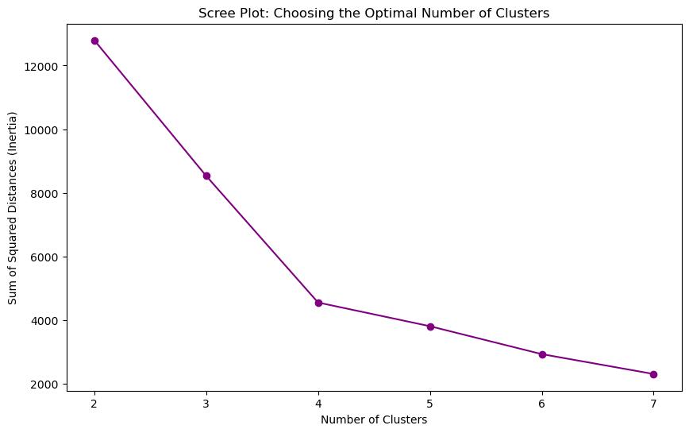

```python
# Scree Plot
sum_squared_distances = []
range_n_clusters = [2, 3, 4, 5, 6, 7]
for num_clusters in range_n_clusters:
    kmeans = KMeans(n_clusters=num_clusters, max_iter=50, random_state=42)
    kmeans.fit(rfm_features)  # Use the  RFM features

    sum_squared_distances.append(kmeans.inertia_)  # Append the inertia (SSD) for each k

# Plot the SSDs for each number of clusters
plt.figure(figsize=(10, 6))
plt.plot(range_n_clusters, sum_squared_distances, marker='o', color='purple')
plt.title('Scree Plot: Choosing the Optimal Number of Clusters')
plt.xlabel('Number of Clusters')
plt.ylabel('Sum of Squared Distances (Inertia)')
plt.show()

# Note: 4 clusters looks good
```

##### Counts Plot of Cluster & Box Plots of Clusters

```python
# Count the number of merchants in each cluster
cluster_counts = rfm_scaled_df['cluster'].value_counts()

# Create the bar plot
plt.bar(cluster_counts.index, cluster_counts.values)

# Add data labels to the bars
for i, count in enumerate(cluster_counts.values):
    plt.text(i, count, str(count), ha='center', va='bottom')

# Set the x-axis labels
plt.xticks(cluster_counts.index)

# Set the title and labels
plt.title('Value Counts of Clusters by Merchant')
plt.xlabel('Cluster')
plt.ylabel('Count')

# Show the plot
plt.show()
```

[output not shown]

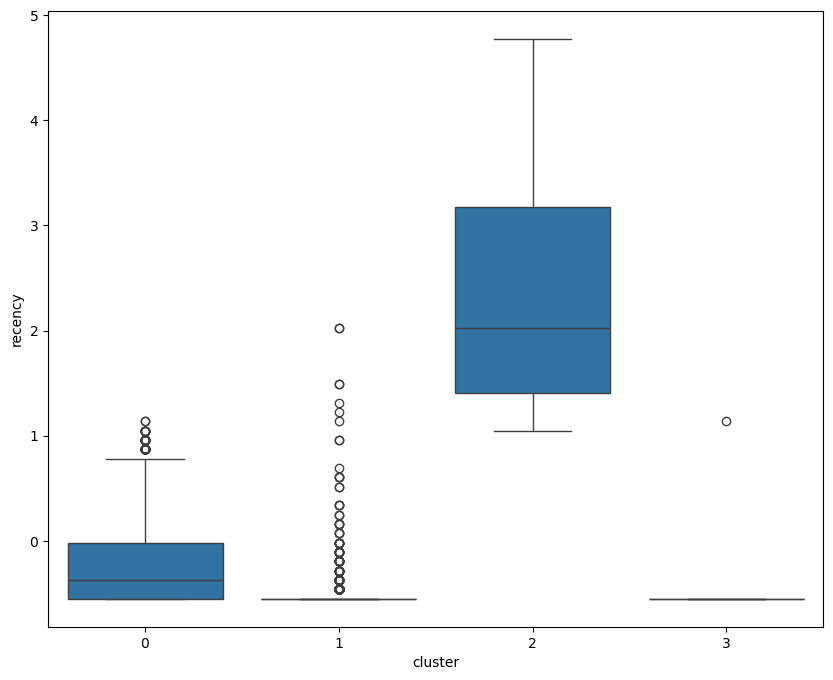

```python
sns.boxplot(x='cluster', y='recency', data=rfm_scaled_df)
```

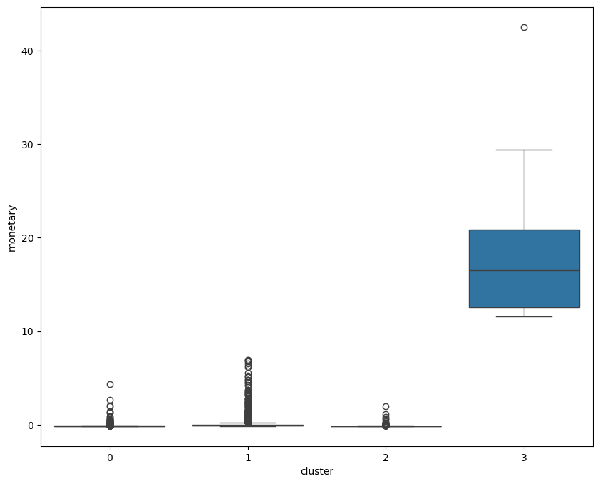

```python
sns.boxplot(x='cluster', y='monetary', data=rfm_scaled_df)
```

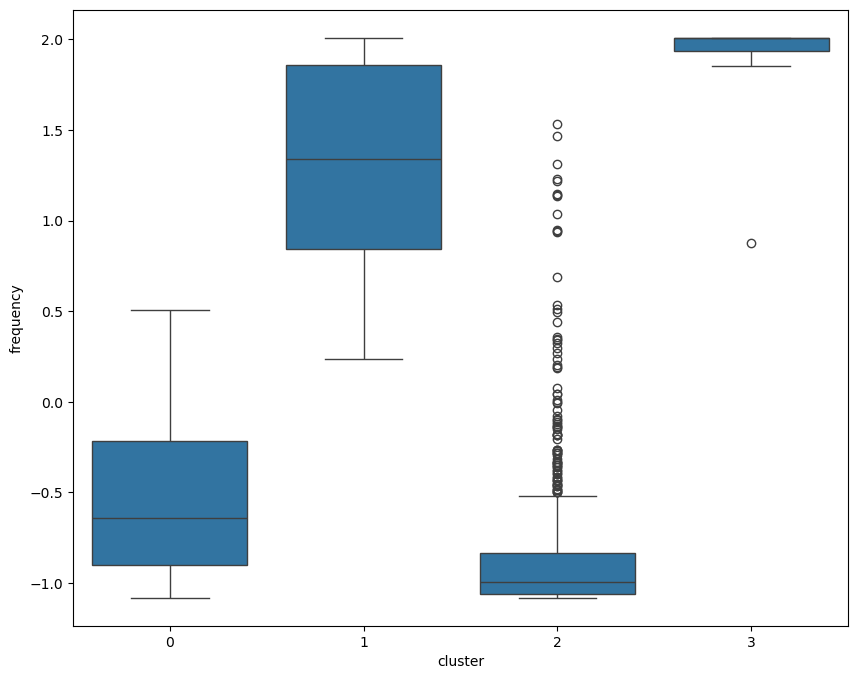

```python
sns.boxplot(x='cluster', y='frequency', data=rfm_scaled_df)
```

##### 2D RFM Scatterplots

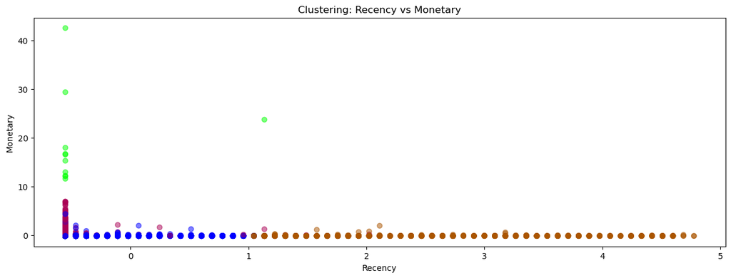

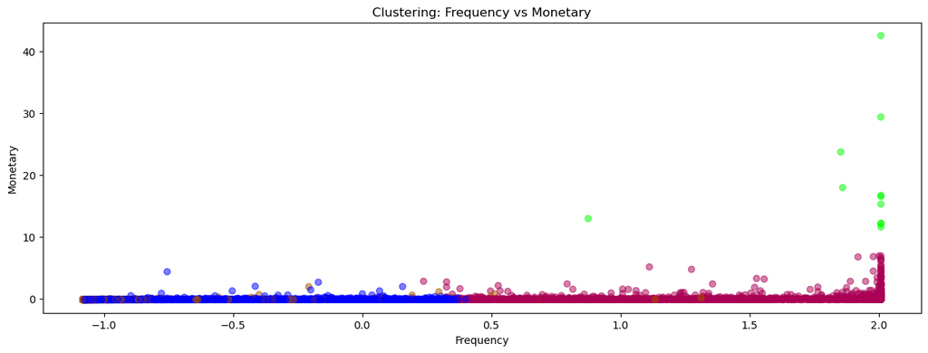

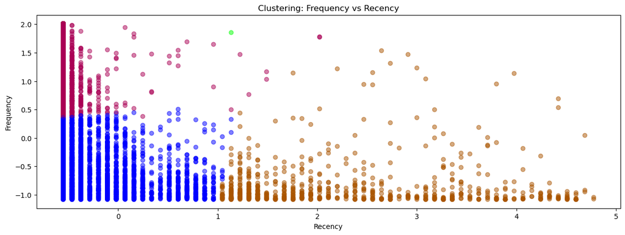

```python
plt.rcParams["figure.figsize"] = (15,5)
colormap = cm.get_cmap('brg')

plt.subplots()
plt.scatter(x=rfm_scaled_df['recency'], y=rfm_scaled_df['monetary'],
            c=rfm_scaled_df['cluster'], cmap=colormap, alpha=0.5)
plt.xlabel('Recency')
plt.ylabel('Monetary')
# plt.ylim(0, 10)
plt.title("Clustering: Recency vs Monetary")

plt.subplots()
plt.scatter(x=rfm_scaled_df['frequency'], y=rfm_scaled_df['monetary'],
            c=rfm_scaled_df['cluster'], cmap=colormap, alpha=0.5)
plt.xlabel('Frequency')
plt.ylabel('Monetary')
# plt.ylim(0, 10)
plt.title("Clustering: Frequency vs Monetary")

plt.subplots()
plt.scatter(x=rfm_scaled_df['recency'], y=rfm_scaled_df['frequency'],
            c=rfm_scaled_df['cluster'], cmap=colormap, alpha=0.5)
plt.xlabel('Recency')
plt.ylabel('Frequency')
plt.title("Clustering: Frequency vs Recency")
```

##### 3D RFM Scatterplot

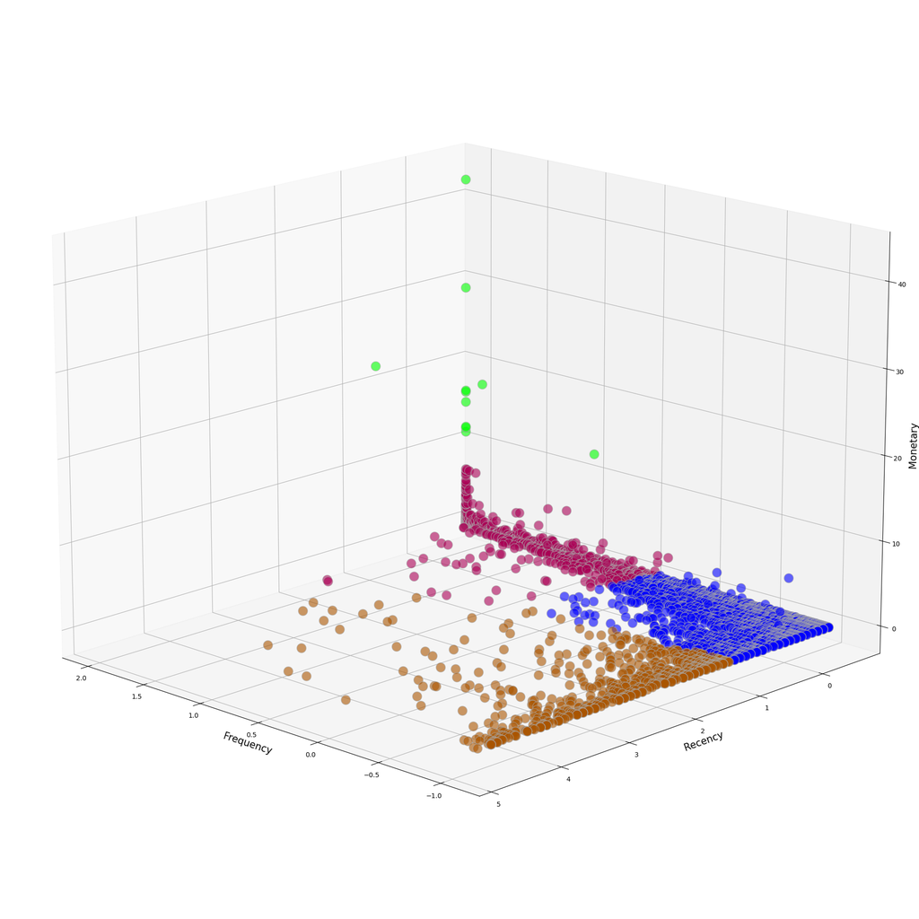

```python
# Set figure size
plt.rcParams["figure.figsize"] = (25, 25)

# Initialize the 3D plot
fig = plt.figure()
ax = fig.add_subplot(111, projection='3d', elev=16, azim=134)

# Plotting the 3D scatter plot
scatter = ax.scatter(
    rfm_scaled_df['frequency'],
    rfm_scaled_df['recency'],
    rfm_scaled_df['monetary'],
    c=rfm_scaled_df['cluster'],
    s=200,
    cmap='brg',
    alpha=0.6,
    edgecolor='darkgrey'
)

# Labeling the axes
ax.set_xlabel('Frequency', fontsize=15)
ax.set_ylabel('Recency', fontsize=15)
ax.set_zlabel('Monetary', fontsize=15)

# Show plot
plt.show()
```

## Export Final Merchant List

```python
# Pick final clusters for targeting
target_clusters = [1, 3]  # Pink is 1, Green is 3

# Filter df for only target clusters
target_merchants_df = rfm_scaled_df[rfm_scaled_df['cluster'].isin(target_clusters)]

output_cols = ['merchant', 'cluster', 'recency', 'frequency', 'monetary', 'used_checkout_or_payment_link']
target_merchants_df = target_merchants_df[output_cols]

target_merchants_df.to_csv('target_merchants.csv', index=False)

target_merchants_df.head(20)
```

|  | merchant | cluster | recency | frequency | monetary | used_checkout_or_payment_link |
| --- | --- | --- | --- | --- | --- | --- |
| 2 | 00491f9d | 1 | -0.551518 | 1.527334 | -0.095694 | 0 |
| 4 | 0076b5fd | 1 | -0.551518 | 1.179021 | 0.010993 | 0 |
| 5 | 007f783b | 1 | -0.551518 | 2.009042 | 5.097195 | 0 |
| 6 | 0093ba4d | 1 | -0.551518 | 1.99422 | 0.296033 | 0 |
| 8 | 00a43c37 | 1 | -0.551518 | 1.99422 | 1.345018 | 0 |
| 12 | 00cfc07f | 1 | -0.018761 | 1.393937 | -0.056744 | 1 |
| 14 | 00ea5a27 | 1 | -0.551518 | 1.74225 | -0.108208 | 0 |
| 15 | 00ef7320 | 1 | -0.551518 | 0.771422 | 0.518071 | 0 |
| 18 | 012258f6 | 1 | -0.551518 | 0.712135 | 0.416945 | 1 |
| 22 | 0164653b | 1 | -0.551518 | 1.038214 | -0.052792 | 0 |
| 26 | 01a8792b | 1 | -0.462725 | 0.860353 | 0.745331 | 1 |
| 27 | 01b09f0c | 1 | -0.462725 | 1.423581 | -0.108111 | 0 |
| 29 | 01d67eee | 1 | -0.462725 | 0.400877 | -0.087902 | 1 |
| 31 | 01e85abb | 1 | -0.551518 | 1.097501 | 0.173558 | 1 |
| 32 | 01f75b05 | 1 | -0.551518 | 0.638026 | -0.118132 | 0 |
| 34 | 01f9bf03 | 1 | -0.551518 | 2.009042 | 0.334932 | 1 |
| 41 | 021de54a | 1 | -0.551518 | 1.66073 | 0.047791 | 1 |
| 44 | 0235e81d | 1 | -0.551518 | 1.305007 | -0.114068 | 0 |
| 46 | 0243626f | 1 | -0.551518 | 1.971987 | -0.050573 | 0 |
| 50 | 026c3371 | 1 | -0.551518 | 2.001631 | -0.068823 | 0 |